# RSquared= no bueno

R-squared does not indicate how well a model fits. When the model is totally right, it may be set to any value.

### Author

Dr. Joshua Hunt

### Published

Dec. 12, 2021

#### R-Squared has a range of values from 0 to 1. The model is doing a “good job” describing the variation in our data if the R-Squared is near 1. If the number is lower, our model can only account for a smaller portion of the data. When you run summary statistics, most applications will offer you R-Squared as an output because it is considered to be a good measurement. One might think of this as a good measurement, however sit is argued that it does not accurately measure the goodness of fit of a model.

**In R, we typically get R-squared by calling the summary function on a model object. Here’s a quick example using simulated data:**

```r
# independent variable
x <- 1:20
# for reproducibility
set.seed(1)
# dependent variable; function of x with random error
y <- 2 + 0.5*x + rnorm(20,0,3)
# simple linear regression
mod <- lm(y~x)
# request just the r-squared value
summary(mod)$r.squared
```

```
[1] 0.6026682
```

**One way to express R-squared is as the sum of squared fitted-value deviations divided by the sum of squared original-value deviations:**

$$R^{2} = \frac{\sum (\hat{y} – \bar{\hat{y}})^{2}}{\sum (y – \bar{y})^{2}}$$
**We can calculate it directly using our model object like so:**

```r
 # extract fitted (or predicted) values from model
f <- mod$fitted.values
# sum of squared fitted-value deviations
mss <- sum((f - mean(f))^2)
# sum of squared original-value deviations
tss <- sum((y - mean(y))^2)
# r-squared
mss/tss
```

```
[1] 0.6026682
```

## $$σ2$$

**R-squared does not measure goodness of fit. It can be arbitrarily low when the model is completely correct. By makingσ2 large, we drive R-squared towards 0, even when every assumption of the simple linear regression model is correct in every particular.**

**What is σ2? When we perform linear regression, we assume our model almost predicts our dependent variable. The difference between “almost” and “exact” is assumed to be a draw from a Normal distribution with mean 0 and some variance we call σ2.**

**This statement is easy enough to demonstrate. The way we do it here is to create a function that (1) generates data meeting the assumptions of simple linear regression (independent observations, normally distributed errors with constant variance), (2) fits a simple linear model to the data, and (3) reports the R-squared. Notice the only parameter for sake of simplicity is sigma. We then “apply” this function to a series of increasing σ values and plot the results.**

```r
r2.0 <- function(sig){
  # our predictor
  x <- seq(1,10,length.out = 100)
  # our response; a function of x plus some random noise
  y <- 2 + 1.2*x + rnorm(100,0,sd = sig)
  # print the R-squared value
  summary(lm(y ~ x))$r.squared
}



sigmas <- seq(0.5,20,length.out = 20)
list(sigmas)
```

```
[[1]]
 [1]  0.500000  1.526316  2.552632  3.578947  4.605263  5.631579
 [7]  6.657895  7.684211  8.710526  9.736842 10.763158 11.789474
[13] 12.815789 13.842105 14.868421 15.894737 16.921053 17.947368
[19] 18.973684 20.000000
```

```r
 # apply our function to a series of sigma values
rout <- sapply(sigmas, r2.0)
list(rout)
```

```
[[1]]
 [1] 0.98118743 0.83021264 0.67423813 0.45770203 0.29563611 0.24066700
 [7] 0.19301491 0.10071847 0.08627560 0.01720018 0.04850383 0.16179882
[13] 0.08566214 0.17419969 0.01183174 0.02325234 0.02565740 0.01260240
[19] 0.01882702 0.02117237
```

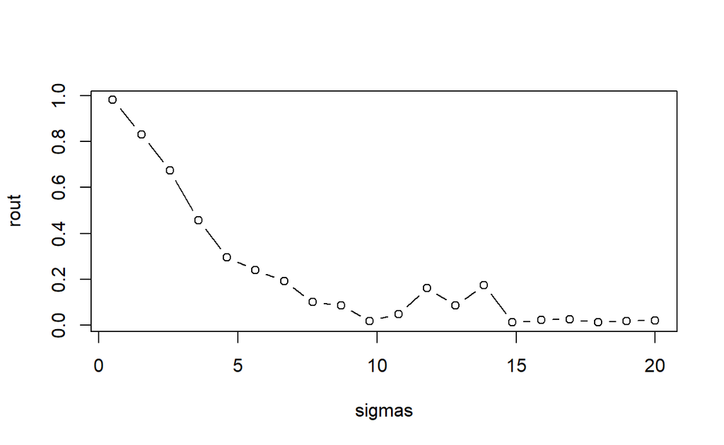

```r
plot(rout ~ sigmas, type="b")
```

R-squared tanks hard with increasing sigma, even though the model is completely correct in every respect.

**R-Squared changed drastically when the standard deviation for a model was increased. This demonstrates that is not always a reliable indicator of an excellent match..**